Waiting for Water

Arizona Indigenous Tribal Water Rights

...or a lack thereof

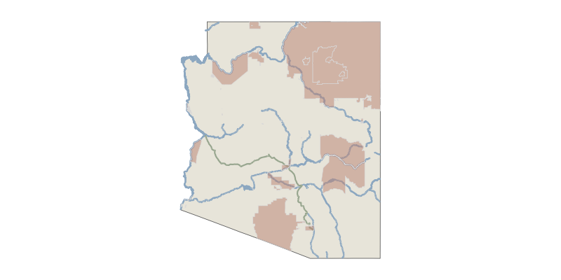

| Tribe |  | Years until water rights after filing<sup>1</sup> | Water Rights <sup>2</sup> | Population | Land | Water<sup>3</sup> |
| --- | --- | --- | --- | --- | --- | --- |
| <a href='https://ak-chin.nsn.us/'>Ak-Chin Indian Community</a><br><div style='font-size: 0.55rem; color: #777;'>+ Ak-Chin Indian Community Off-Reservation Trust Land</div> | NA | 4 | Fully | 2900 | 89.13451 | 0.019164 |
| <a href='https://www.cocopah.com/'>Cocopah Indian Tribe</a><br> | NA | 10 | Adjudicated | 1158 | 25.835843 | 0.077685 |
| <a href='https://www.crit-nsn.gov/'>Colorado River Indian Tribes</a><br> | NA | 10 | Adjudicated | 8385 | 1184.890248 | 17.238466 |
| <a href='https://fmyn.org/'>Fort McDowell Yavapai Nation</a><br> | NA | 11 | Fully | 1006 | 99.91283 | 0.93454 |
| <a href='https://www.fortmojaveindiantribe.com/'>Fort Mojave Indian Tribe</a><br> | NA | 10 | Adjudicated | 1572 | 133.565269 | 2.784365 |
| <a href='https://www.gilariver.org/'>Gila River Indian Community</a><br> | NA | 29 | Fully | 12179 | 1510.990799 | 0.937536 |
| <a href='https://theofficialhavasupaitribe.com/'>Havasupai Tribe</a><br> | NA | 8 | Partially | 730 | 714.393134 | 0 |
| <a href='https://www.hopi-nsn.gov/'>Hopi Tribe</a><br><div style='font-size: 0.55rem; color: #777;'>+ Hopi Off-Reservation Trust Land</div> | NA | 39 | Unresolved | 15790 | 6558.3385 | 2.407606 |
| <a href='https://hualapai-nsn.gov/'>Hualapai Tribe</a><br><div style='font-size: 0.55rem; color: #777;'>+ Hualapai Off-Reservation Trust Land</div> | NA | 29 | Fully | 3476 | 4149.479135 | 8.118425 |
| <a href='https://www.kaibabpaiute-nsn.gov/'>Kaibab-Paiute Tribe</a>*<br> | NA | 0 | Unresolved | 249 | 489.295372 | 0.01992 |

[output cut: 11 more lines]

* Kaibab Band of Paiute Indians has not filed a water claim yet.  
<sup>1</sup> The Winters Doctrine, from the 1908 Supreme Court case [*Winters v. United States*](https://en.wikipedia.org/wiki/Winters_v._United_States#:~:text=Winters%20v.%20United%20States%2C%20207%20U.S.%20564%20%281908%29%2C,cases%20where%20the%20rights%20were%20not%20clear.%20) , established that Native American tribes have reserved water rights when reservations are created. These rights are considered to have a priority date corresponding to the establishment date of the reservation, making them senior to many other water rights.  
<sup>2</sup> Adjudicated Water Rights resulted from the set of United States Supreme Court cases. [*Arizona v. California*](https://en.wikipedia.org/wiki/Arizona_v._California) , which all deal with disputes over water distribution from the Colorado River between the states of Arizona and California.  
<sup>3</sup> Water is derived from the geographic area within the reservation and does not represent the amount of water allotted by water rights claims. This column serves instead to showcase the amount of water bordering or running through a reservation, but the Tribe may not have actual claims to use this water.

Data Sources: Wikipedia, US Census Bureau, ProPublica.org, and AZ Geo Data Hub | Gchism94